# Get started with giscoR

# Introduction

*The full site with more examples and vignettes is available at https://ropengov.github.io/giscoR/.*

[**giscoR**](https://ropengov.github.io/giscoR/) is a package designed to provide a simple interface to the Eurostat [GISCO geodata distribution](https://gisco-services.ec.europa.eu/distribution/v2/).

GISCO provides geospatial data for the European Union, its member states and subnational regions. It supplies geospatial files in different formats, with a focus on Europe and global datasets such as country boundaries, labels and coastal lines.

GISCO supplies data at multiple resolutions: high-resolution datasets for small areas (01M, 03M) and lighter datasets for larger areas (10M, 20M, 60M). Datasets are available in three coordinate reference systems: [EPSG:4326](https://epsg.io/4326), [EPSG:3035](https://epsg.io/3035) and [EPSG:3857](https://epsg.io/3857).

**giscoR** returns [**sf** package objects](https://r-spatial.github.io/sf/reference/sf.html). See https://r-spatial.github.io/sf/ for details.

# Caching

**giscoR** supports caching downloaded datasets. Set the cache directory with:

```r
gisco_set_cache_dir("./path/to/location")
```

If a file is not available locally, it is downloaded to that directory so subsequent requests for the same data can read from the local cache.

If downloading fails, you can manually download the file from the [GISCO geodata distribution](https://gisco-services.ec.europa.eu/distribution/v2/) and place it in your local cache directory.

# Downloading data

Review the following attribution and licensing requirements before using GISCO data:

## General copyright

> [Eurostat’s general copyright notice and license policy](https://ec.europa.eu/eurostat/web/main/help/copyright-notice) applies. Some datasets have additional download and usage provisions. The download and use of these data are subject to acceptance of those provisions. See the [administrative units](https://ec.europa.eu/eurostat/web/gisco/geodata/administrative-units) and [statistical units](https://ec.europa.eu/eurostat/web/gisco/geodata/statistical-units) for more details.

Source: https://ec.europa.eu/eurostat/web/gisco/geodata

The `gisco_attributions()` function provides guidance on this topic and returns attribution text in several languages.

```r
library(giscoR)
c(
  gisco_attributions(lang = "en"),
  gisco_attributions(lang = "fr"),
  gisco_attributions(lang = "de")
) |> cat(sep = "\n\n")
```

```
#> © EuroGeographics for the administrative boundaries
#>
#> © EuroGeographics pour les limites administratives
#>
#> © EuroGeographics bezüglich der Verwaltungsgrenzen
```

# Basic example

The following example downloads EU member states and candidate countries for 2024.

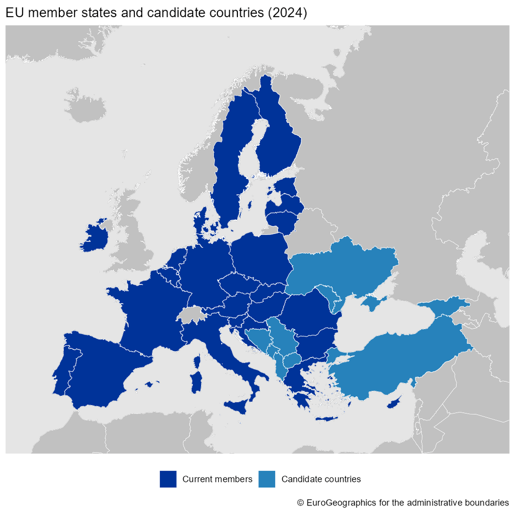

EU member states and candidate countries (2024)

```r
library(dplyr)
library(ggplot2)
world <- gisco_get_countries(resolution = 3, epsg = 3035)

world <- world |>
  mutate(
    status = case_when(
      EU_STAT == "T" ~ "Current members",
      CC_STAT == "T" ~ "Candidate countries",
      TRUE ~ NA
    ),
    # Set levels.
    status = factor(status,
      levels = c("Current members", "Candidate countries")
    )
  )

ggplot(world) +
  geom_sf(fill = "#c1c1c1") +
  geom_sf(aes(fill = status), color = "white") +
  guides(fill = guide_legend(direction = "horizontal")) +
  # Center on Europe with EPSG 3035.
  coord_sf(
    xlim = c(2377294, 7453440),
    ylim = c(1313597, 5628510)
  ) +
  scale_fill_manual(
    values = c("#039", "#2782bb"), na.value = "#c1c1c1",
    na.translate = FALSE
  ) +
  theme_minimal() +
  theme(
    panel.background = element_rect(fill = "grey90", color = NA),
    axis.line = element_blank(),
    axis.text = element_blank(),
    panel.grid = element_blank(),
    legend.position = "bottom"
  ) +
  labs(
    title = "EU member states and candidate countries (2024)",
    caption = gisco_attributions(),
    fill = ""
  )
```

You can select specific countries by name in any language, ISO 3166-1 alpha-3 codes or Eurostat codes. However, you cannot mix these identifier types in a single call.

You can also combine datasets by using the same `resolution`, `epsg` and (optionally) `year`:

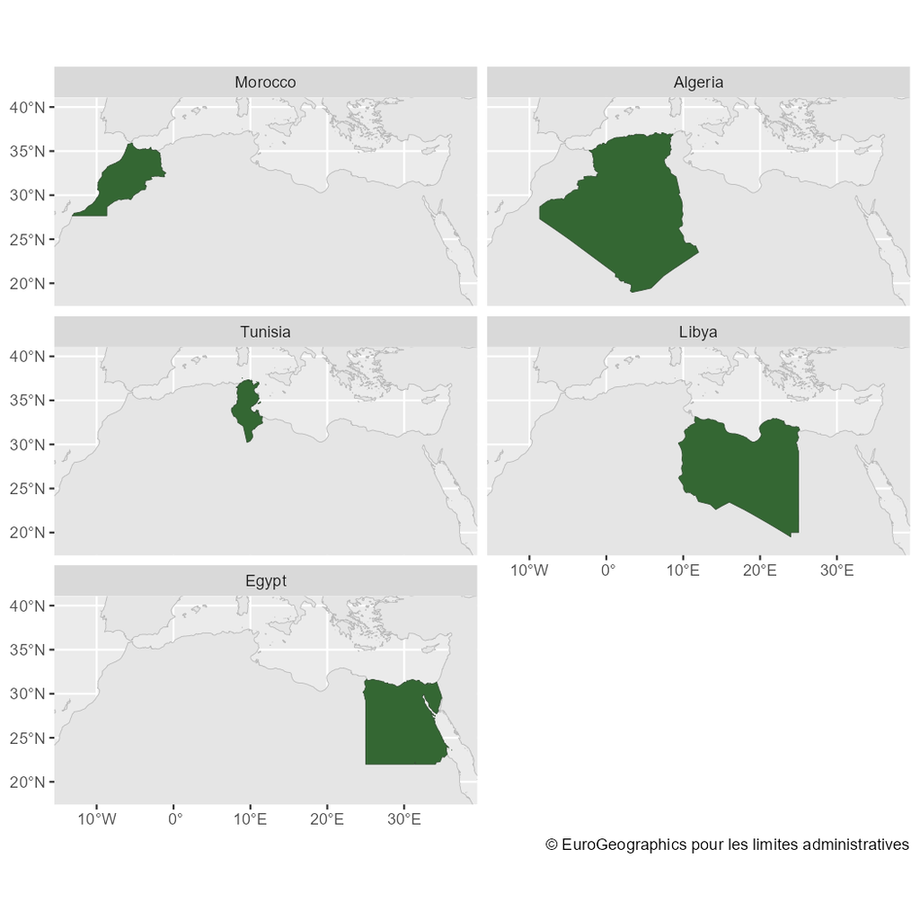

Political map of North Africa

```r
cntr <- c("Morocco", "Algeria", "Tunisia", "Libya", "Egypt")

africa_north <- gisco_get_countries(
  country = cntr,
  resolution = "03",
  epsg = "4326", year = "2024"
)

# Order plot facets.
africa_north$NAME_ENGL <- factor(africa_north$NAME_ENGL, levels = cntr)

# Get coastal lines.
coast <- gisco_get_coastal_lines(
  resolution = "03",
  epsg = "4326",
  year = "2016"
)

# Create plot.
ggplot(coast) +
  geom_sf(color = "#B9B9B9") +
  geom_sf(data = africa_north, fill = "#346733", color = "#335033") +
  coord_sf(xlim = c(-13, 37), ylim = c(18.5, 40)) +
  facet_wrap(vars(NAME_ENGL), ncol = 2) +
  labs(caption = gisco_attributions("fr"))
```

# Thematic maps with **giscoR**

This example shows how **giscoR** can be used with Eurostat data. For plotting, we use the **ggplot2** package. Any package that supports **sf** package objects, such as **tmap**, **mapsf** or **leaflet**, can be used.

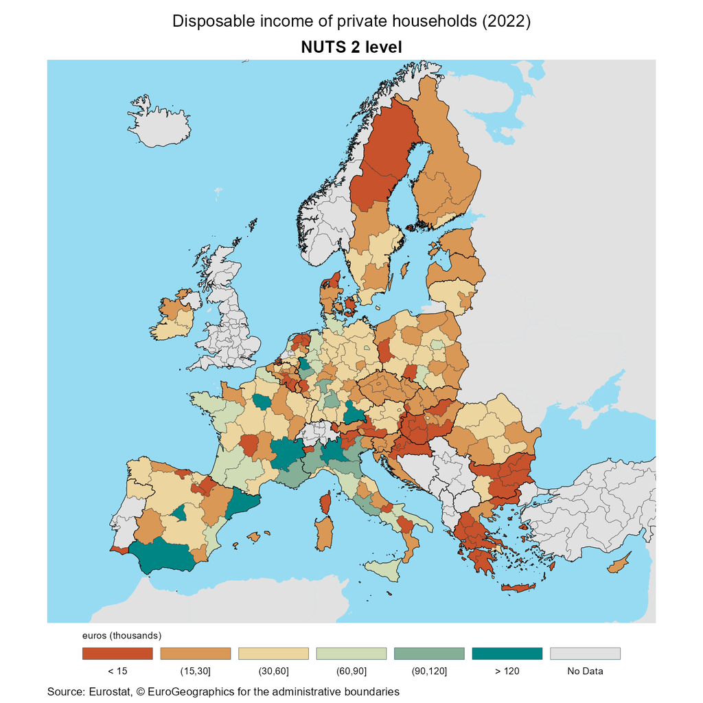

Disposable income of private households by NUTS 2 regions (2022)

```r
# Load EU member data.
library(giscoR)
library(dplyr)
library(eurostat)
library(ggplot2)

nuts2 <- gisco_get_nuts(
  year = "2021", epsg = "3035", resolution = "10",
  nuts_level = "2"
)
# Get country borders.
borders <- gisco_get_countries(epsg = "3035", year = "2020", resolution = "3")

eu_bord <- borders |>
  filter(CNTR_ID %in% nuts2$CNTR_CODE)

# Retrieve disposable income data from Eurostat.
pps <- get_eurostat("tgs00026") |>
  filter(TIME_PERIOD == "2022-01-01")

nuts2_sf <- nuts2 |>
  left_join(pps, by = "geo") |>
  mutate(
    values_th = values / 1000,
    categ = cut(values_th, c(0, 15, 30, 60, 90, 120, Inf))
  )

# Adjust labels.
labs <- levels(nuts2_sf$categ)
labs[1] <- "< 15"
labs[6] <- "> 120"
levels(nuts2_sf$categ) <- labs

# Create the plot.
ggplot(nuts2_sf) +
  # Add background geometry.
  geom_sf(data = borders, fill = "#e1e1e1", color = NA) +
  geom_sf(aes(fill = categ), color = "grey20", linewidth = .1) +
  geom_sf(data = eu_bord, fill = NA, color = "black", linewidth = .15) +
  # Center on Europe with EPSG 3035.
  coord_sf(xlim = c(2377294, 6500000), ylim = c(1413597, 5228510)) +
  # Configure legends and color.
  scale_fill_manual(
    values = hcl.colors(length(labs), "Geyser", rev = TRUE),
    # Label missing values.
    labels = function(x) {
      ifelse(is.na(x), "No Data", x)
    },
    na.value = "#e1e1e1"
  ) +
  guides(fill = guide_legend(nrow = 1)) +
  theme_void() +
  theme(
    text = element_text(colour = "grey0"),
    panel.background = element_rect(fill = "#97dbf2"),
    panel.border = element_rect(fill = NA, color = "grey10"),
    plot.title = element_text(hjust = 0.5, vjust = -1, size = 12),
    plot.subtitle = element_text(
      hjust = 0.5, vjust = -2, face = "bold",
      margin = margin(b = 10, t = 5), size = 12
    ),
    plot.caption = element_text(
      size = 8, hjust = 0, margin =
        margin(b = 4, t = 8)
    ),
    legend.text = element_text(size = 7, ),
    legend.title = element_text(size = 7),
    legend.position = "bottom",
    legend.direction = "horizontal",
    legend.text.position = "bottom",
    legend.title.position = "top",
    legend.key.height = rel(0.5),
    legend.key.width = unit(0.1, "npc")
  ) +
  # Add labels.
  labs(
    title = "Disposable income of private households (2022)",
    subtitle = "NUTS 2 level",
    fill = "euros (thousands)",
    caption = paste0(
      "Source: Eurostat, ", gisco_attributions()
    )
  )
```

Use these examples as a starting point for your own maps.